# Regressions

Tianran Zhang

6/20/2020

```r
load("../Data/ESP_reg.RData")
load("../Data/PIAAC_reg.RData")
```

```r
ESP.reg$visits3 <- ifelse(ESP.reg$visits == "Never", "Never",
                          ifelse(ESP.reg$visits %in% c("1-2 times", "Once every few months"), "Not Regular", "Regular"))

ESP.reg$visits3 <- factor(ESP.reg$visits3, levels = c("Never", "Not Regular", "Regular"))
```

# Empire State Poll (ESP)

## Investigate the association between numeracy and self-reported health status

- Outcome: binary health status
1. Original Levels (Multi-level/Excellent/Very good/Good/Fair/Poor/Unknown)
2. Health status (Binary): Good VS. Not Good
- Predictor: numeracy score
- Covariates: gender, age, education, income, race, ethincity
- Interaction term: education & numeracy score

### Univariate Regressions

```r
univ <- function(var, y, dat){
  form = formula(paste0(y, " ~ ", var))
  logit = glm(form, data = dat, family = "binomial")
  OR = data.frame(exp(cbind(OR = coef(logit), confint(logit))))[-1, ]
  OR = cbind(var, OR, coef(summary(logit))[-1, 4])
  colnames(OR) <- c("Covariate", "OR", "2.5%", "97.5%", "p-val")
  # OR$sig <- ifelse(OR$`p-val` < 0.05, "*", "")
  return(OR)
}

varlist1 <- c("numeracy", "gender", "age.cat", "educ",
              "income.cat", "race", "hisp")
univ_summary1 <- do.call(rbind.data.frame,
                        lapply(varlist1, univ,
                               y = "health_status_good",
                               dat = ESP.reg))
univ_summary1 %>%
  kable() %>%
  kable_styling()
```

|  | Covariate | OR | 2.5% | 97.5% | p-val |
| --- | --- | --- | --- | --- | --- |
| numeracy | numeracy | 1.1310087 | 1.0745536 | 1.1907181 | 0.0000024 |
| genderFemale | gender | 1.1223249 | 0.7865289 | 1.6043380 | 0.5251103 |
| age.cat21-44 | age.cat | 0.3344498 | 0.0788065 | 0.9684247 | 0.0764244 |
| age.cat45-64 | age.cat | 0.3452012 | 0.0811972 | 1.0029841 | 0.0859788 |
| age.cat65+ | age.cat | 0.2148103 | 0.0501016 | 0.6340164 | 0.0139635 |
| educSome college or associate’s degree | educ | 2.6327787 | 1.6722560 | 4.1862792 | 0.0000343 |
| educBachelor’s degree or higher | educ | 4.5096573 | 2.9231403 | 7.0190585 | 0.0000000 |
| income.cat$50k-$100k | income.cat | 3.3088235 | 2.1361507 | 5.2205767 | 0.0000001 |
| income.cat$100k-$150k | income.cat | 2.5277778 | 1.4579345 | 4.5790464 | 0.0014129 |
| income.cat$150k+ | income.cat | 3.9687500 | 2.2711314 | 7.3259279 | 0.0000035 |
| raceBlack | race | 0.5924866 | 0.3622596 | 0.9917385 | 0.0409053 |
| raceOther | race | 0.6859097 | 0.4422673 | 1.0816513 | 0.0975630 |
| hispNon-hispanic | hisp | 1.9029966 | 1.2114110 | 2.9442392 | 0.0044069 |

```r
sig.var <- univ_summary1 %>%
  filter(`p-val` < 0.05) %>%
  select(Covariate)
sig.var <- unique(sig.var$Covariate)
```

Based on the summary table above, 6 variables are significant covariates of people’s health status numeracy, age.cat, educ, income.cat, race, hisp.

### Multivariate Regressions

```r
n <- nrow(ESP.reg)

set.seed(135)
id <- sample(n, n * .6)
ESP.training <- ESP.reg[id, ]
ESP.test <- ESP.reg[-id, ]
```

**Unweighted Regressions**

```r
ESP.reg$health_status_good <- relevel(ESP.reg$health_status_good,
                                      ref = "Good")
full1 <- glm(health_status_good ~ numeracy + gender + age.cat +
               educ + income.cat + race + hisp+
               educ:numeracy, data = ESP.reg, family = "binomial")
final1 <- step(full1, direction = "both", trace = 0)
# summary(final1)
fit1 <- glm(health_status_good ~ numeracy + age.cat + educ +
              income.cat, data = ESP.reg, family = "binomial")

multi_summary1 <- exp(cbind(coef(fit1), confint(fit1))[-1, ]) %>% as.data.frame()
colnames(multi_summary1)[1] <- "OR"
multi_summary1$`p-val` <- summary(fit1)$coefficients[-1, 4]

kable(multi_summary1) %>%
  kable_styling()
```

|  | OR | 2.5 % | 97.5 % | p-val |
| --- | --- | --- | --- | --- |
| numeracy | 0.9408120 | 0.8880810 | 0.9970226 | 0.0383557 |
| age.cat21-44 | 4.8248533 | 1.6023285 | 20.9627085 | 0.0131470 |
| age.cat45-64 | 4.8759895 | 1.6120494 | 21.2295048 | 0.0127742 |
| age.cat65+ | 6.8626507 | 2.2310924 | 30.1657798 | 0.0027441 |
| educSome college or associate’s degree | 0.4335870 | 0.2659279 | 0.7014795 | 0.0007160 |
| educBachelor’s degree or higher | 0.3001718 | 0.1824655 | 0.4910541 | 0.0000018 |
| income.cat$50k-$100k | 0.4206950 | 0.2599475 | 0.6717320 | 0.0003385 |
| income.cat$100k-$150k | 0.6383839 | 0.3390678 | 1.1620431 | 0.1512670 |
| income.cat$150k+ | 0.4570530 | 0.2344569 | 0.8557625 | 0.0171745 |

```r
# power calculation
power1 <- powerSim(final1, nsim = 100,  progress = FALSE)
auc1 <- auc(ESP.reg$health_status_good, predict.glm(fit1, ESP.reg, type = "response"))

# Calculate error rate
fit1.train <- glm(health_status_good ~ numeracy + age.cat + educ +
              income.cat, data = ESP.training, family = "binomial")
pred1 <- predict(fit1.train, ESP.test, type = "response")
pred1 <- ifelse(pred1 > .5, "Good", "Not Good")
err1 <- mean(pred1 != ESP.test$health_status_good)
```

Step-wise selection method was conducted. The final model contains four significant predictors: numeracy, age, education, and income. The power for our final model is 0.81, with an AUC of 0.7237434. The prediction error rate is 0.219.

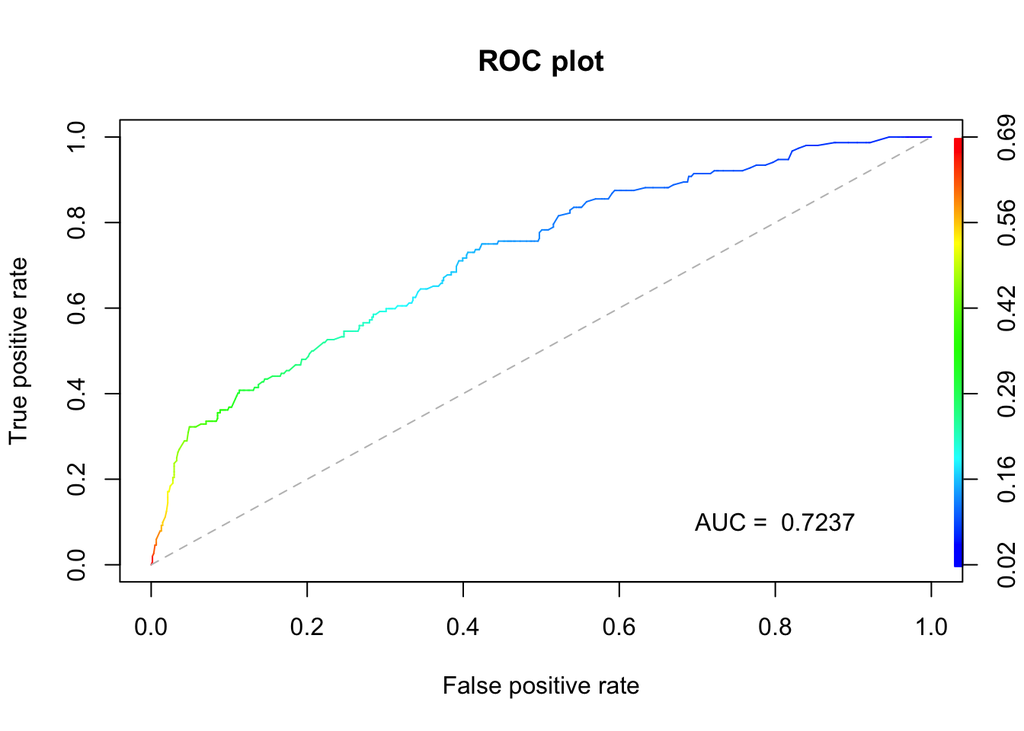

```r
# ROC curve
rocplot <- function(truth, pred, ...){
  predob = prediction(pred, truth)
  perf = performance(predob, "tpr", "fpr")
  plot(perf, colorize=T, ...)
  area = auc(truth, pred)
  area = format(round(area, 4), nsmall = 4)
  text(x = .8, y = .1, labels = paste("AUC = ", area))
  segments(x0 = 0, y0 = 0, x1 = 1, y1 = 1, col = "gray", lty = 2)
}

rocplot(ESP.reg$health_status_good, predict.glm(fit1, ESP.reg, type = "response"), title = "ROC plot")
title(main = "ROC plot")
```

**Weighted Regressions**  
Based on the comparison table between ESP and NYS, education, income and race are three variables that have different different distributions in ESP data and NYS dataset. Add weights to adjust the proportion of these three variables and refit the multi-regression model, education and income are significant covariates. So, we only add weights to adjust the proportion of education and income. Weights are calculated based on manual iterative solution.

```r
# This function generate survey weights automatically
surv.wt <- function(x, w, col_name){
  # x: dataset of interest
  # w: NYS percentages
  # cpl_pos: column number of the variable to be weighted
  # col_name: name of the variable to be weighted
  #x <- ESP.weighted; w <- wt.edu; col_pos<- 5; col_name <- "educ"
  col_pos <- which(colnames(x) == col_name)
  x1 <- x %>%
    group_by_at(col_pos) %>%
    summarise(wt = sum(wt)/nrow(x)) %>%
    mutate(wt_new = w/wt) %>%
    select(-wt)

  merge(x, x1, by = col_name) %>%
    mutate(wt = wt * wt_new) %>%
    select(-wt_new)
}

# This function check if weighted ESP is significant different
# compared to NYS

fisher.sig <- function(x, col_name, w2){
  col_pos <- which(colnames(x) == col_name)
  x1 <- x %>%
    group_by_at(col_pos) %>%
    summarise(w = sum(wt))
  fisher.test(matrix(c(x1$w, w2), byrow = T, ncol = length(w2)),
              simulate.p.value = T)$p.value
}
```

```r
# Manully input the NYS education level proportion and hispanic proportion

ESP.weighted <- ESP.reg %>%
  mutate(wt = 1)

wt.educ <- c(97506, 69577, 83478)
wt.income <- c(51303, 64932, 19158, 19930)
wt.race <- c(13559, 3424, 2471)

# 1st iterative
ESP.weighted <- surv.wt(ESP.weighted, wt.educ/sum(wt.educ), "educ")
ESP.weighted <- surv.wt(ESP.weighted, wt.income/sum(wt.income), "income.cat")
# ESP.weighted <- surv.wt(ESP.weighted, wt.race/sum(wt.race), "race")

# Check p-values for fisher.tests
# fisher.sig(ESP.weighted, "educ", wt.educ)
# fisher.sig(ESP.weighted, "income.cat", wt.income)
# fisher.sig(ESP.weighted, "race", wt.race)
```

```r
full2 <- glm(health_status_good ~ numeracy + gender + age.cat +
               educ + income.cat + race + hisp, weights = wt,
             data = ESP.weighted, family = "binomial")
final2 <- step(full2, direction = "both", trace = 0)

fit2 <- glm(health_status_good ~ numeracy + age.cat +
               educ + income.cat +hisp, weights = wt,
             data = ESP.weighted, family = "binomial")
fit2.unweight <- glm(health_status_good ~ numeracy + age.cat +
               educ + income.cat +hisp,
               data = ESP.weighted, family = "binomial")

multi_summary2 <- exp(cbind(coef(fit2), confint(fit2))[-1, ]) %>% as.data.frame()
colnames(multi_summary2)[1] <- "OR"
multi_summary2$`p-val` <- summary(fit2)$coefficients[-1, 4]

# power calculation
power2 <- powerSim(fit2, sim = fit2.unweight, nsim = 1000,
                   progress = FALSE)
auc2 <- auc(ESP.weighted$health_status_good, predict.glm(fit2, ESP.weighted, weights = wt, type = "response"))

kable(multi_summary2) %>%
  kable_styling()
```

|  | OR | 2.5 % | 97.5 % | p-val |
| --- | --- | --- | --- | --- |
| numeracy | 0.9250619 | 0.8757010 | 0.9768844 | 0.0051482 |
| age.cat21-44 | 4.8866095 | 1.8648349 | 16.2931829 | 0.0033560 |
| age.cat45-64 | 5.9164356 | 2.2453680 | 19.8101737 | 0.0010721 |
| age.cat65+ | 7.2008336 | 2.6655593 | 24.4991061 | 0.0003666 |
| educSome college or associate’s degree | 0.5102401 | 0.3236786 | 0.7956869 | 0.0033004 |
| educBachelor’s degree or higher | 0.3587504 | 0.2144383 | 0.5895572 | 0.0000678 |
| income.cat$50k-$100k | 0.3873225 | 0.2511593 | 0.5927010 | 0.0000144 |
| income.cat$100k-$150k | 0.5552666 | 0.2866863 | 1.0326157 | 0.0704119 |
| income.cat$150k+ | 0.4489146 | 0.2128162 | 0.8924817 | 0.0274144 |
| hispNon-hispanic | 0.5764680 | 0.3670891 | 0.9111345 | 0.0173437 |

```r
# lastResult()$error

# Calculate error rate
fit2.train <- glm(health_status_good ~ numeracy + age.cat +
               educ + income.cat +hisp, weights = wt,
             data = ESP.weighted[id, ], family = "binomial")
pred2 <- predict(fit2.train, ESP.test, type = "response")
pred2 <- ifelse(pred2 > .5, "Not Good", "Good")
err2 <- mean(pred2 != ESP.test$health_status_good)
```

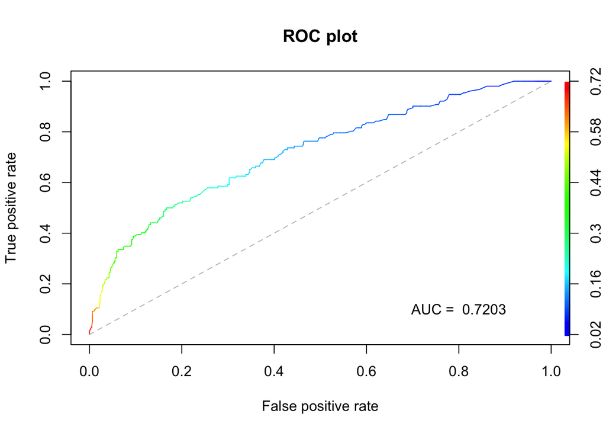

```r
# ROC curve
rocplot(ESP.weighted$health_status_good, predict.glm(fit2, ESP.weighted, weights = wt, type = "response"), title = "ROC plot")
title(main = "ROC plot")
```

## Investigate the association between numeracy and visits to doctors (3 levels)

- Outcome:visits to doctors
  1. Original Levels (Never/1-2 times/Once every few months/Once a month/Twice a month/Once a week/2-3 times a week)
  2. Visit status (Binary): Never (# visits = 0) VS. Not Regular (#visits <=2) VS. Regular (#visits >= 3)
  3. Stratified by Gender
- Predictor: numeracy score
- Covariates: egnder, age, education, income, race, ethincity

```r
table(ESP.reg$visits)
```

```
##
##                 Never             1-2 times Once every few months
##                    68                   223                   288
##          Once a month         Twice a month           Once a week
##                    96                    55                    23
##      2-3 times a week
##                    10
```

```r
tab1 <- table(ESP.reg$visits, ESP.reg$gender)
tab1
```

```
##
##                         Male Female
##   Never                   50     18
##   1-2 times              118    105
##   Once every few months  144    144
##   Once a month            38     58
##   Twice a month           25     30
##   Once a week             12     11
##   2-3 times a week         2      8
```

```r
fisher.test(tab1, simulate.p.value = TRUE)
```

```
##
##  Fisher's Exact Test for Count Data with simulated p-value (based on
##  2000 replicates)
##
## data:  tab1
## p-value = 0.001499
## alternative hypothesis: two.sided
```

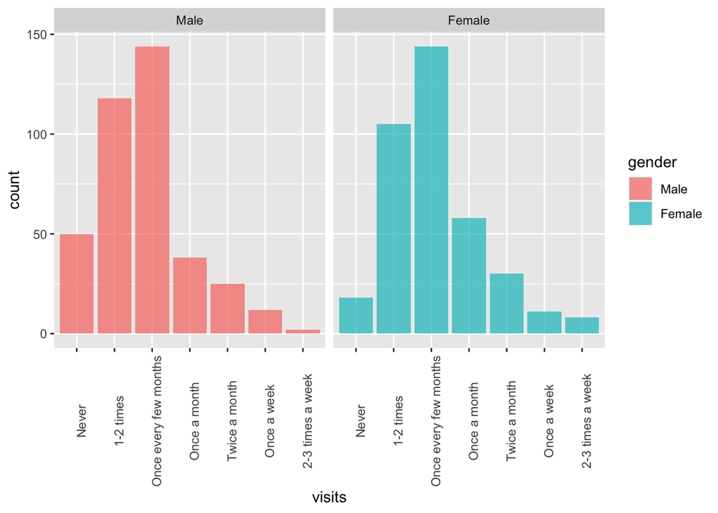

```r
ggplot(data = ESP.reg) +
  geom_histogram(mapping = aes(x = visits, group = gender, fill = gender), position = "identity", stat = "count", alpha = .7) +
  facet_wrap(~gender) +
  theme(axis.text.x = element_text(angle = 90))
```

### Univariate Regressions

```r
univ1 <- function(var, y, dat){
  form = formula(paste0(y, " ~ ", var))
  logit = clm(form, data = dat)
  OR = data.frame(exp(cbind(OR = coef(logit)[c(-1, -2)], confint(logit))))
  OR = cbind(var, OR, summary(logit)$coefficients[c(-1, -2), 4])
  colnames(OR) <- c("Covariate", "OR", "2.5%", "97.5%", "p-val")
  #OR$sig <- ifelse(OR$`p-val` < 0.05, "*", "")
  return(OR)
}
```

```r
univ_summary2 <- rbind(univ1("numeracy", "visits3", ESP.reg),
univ1("gender", "visits3", ESP.reg),
univ1("age.cat", "visits3", ESP.reg),
univ1("educ", "visits3", ESP.reg),
univ1("income.cat", "visits3", ESP.reg),
univ1("race", "visits3", ESP.reg),
univ1("hisp", "visits3", ESP.reg))

sig.var2 <- univ_summary2 %>%
  filter(`p-val` < 0.05) %>%
  select(Covariate)
sig.var2 <- unique(sig.var2$Covariate)

univ_summary2 %>%
  kable() %>%
  kable_styling()
```

|  | Covariate | OR | 2.5% | 97.5% | p-val |
| --- | --- | --- | --- | --- | --- |
| numeracy | numeracy | 0.9628347 | 0.9195666 | 1.0083891 | 0.1070289 |
| genderFemale | gender | 1.8768259 | 1.3874705 | 2.5487893 | 0.0000488 |
| age.cat21-44 | age.cat | 1.0464920 | 0.5351401 | 2.0775992 | 0.8955600 |
| age.cat45-64 | age.cat | 1.0011296 | 0.5111581 | 1.9897766 | 0.9974030 |
| age.cat65+ | age.cat | 1.7738919 | 0.8820260 | 3.6262398 | 0.1120394 |
| educSome college or associate’s degree | educ | 1.0471963 | 0.6863261 | 1.5997346 | 0.8307338 |
| educBachelor’s degree or higher | educ | 1.1693776 | 0.8015703 | 1.7121065 | 0.4186743 |
| income.cat$50k-$100k | income.cat | 0.9234770 | 0.6407852 | 1.3305553 | 0.6690954 |
| income.cat$100k-$150k | income.cat | 0.8172844 | 0.5052538 | 1.3153966 | 0.4082385 |
| income.cat$150k+ | income.cat | 1.2822939 | 0.8380746 | 1.9593797 | 0.2507651 |
| raceBlack | race | 1.1740045 | 0.7504971 | 1.8239340 | 0.4784589 |
| raceOther | race | 0.6264256 | 0.4197681 | 0.9292169 | 0.0209770 |
| hispNon-hispanic | hisp | 1.5866599 | 1.0434082 | 2.4293595 | 0.0322177 |

The univariate proportional odds regressions show that gender, race and hispanic are significant covariates of visits to doctors.

### Multivariate Regressions

**Unweighted Regression**

```r
full3_male <- clm(visits3 ~ numeracy + age.cat + educ + income.cat +
                    race + hisp, subset = gender == "Male", data = ESP.reg)
final3_male <- step(full3_male, direction = "both", trace = 0)
# summary(final3_male)
#fit3_male <- clm(visits3 ~ educ + income.cat,
#                  subset = gender == "Male", data = ESP.reg)
# PH test
nominal_test(final3_male)
```

```
## Tests of nominal effects
##
## formula: visits3 ~ numeracy + age.cat + income.cat + hisp
##            Df  logLik    AIC    LRT Pr(>Chi)
## <none>        -316.85 653.69
## numeracy    1 -315.67 653.34 2.3572   0.1247
## age.cat     3 -314.84 655.67 4.0192   0.2594
## income.cat  3 -314.21 654.42 5.2722   0.1529
## hisp        1 -316.80 655.60 0.0902   0.7639
```

```r
full3_female <- clm(visits3 ~ numeracy + age.cat + educ + income.cat +
                    race + hisp, subset = gender == "Female", data = ESP.reg)
final3_female <- step(full3_female, direction = "both", trace = 0)
# summary(final3_female)
#fit3_female <- clm(visits3 ~ educ + income.cat,
#                   subset = gender == "Female", data = ESP.reg)

# PH test
nominal_test(final3_female)
```

```
## Tests of nominal effects
##
## formula: visits3 ~ age.cat
##         Df  logLik    AIC     LRT Pr(>Chi)
## <none>     -285.08 580.17
## age.cat  3 -284.70 585.40 0.77017   0.8566
```

```r
multi_summary3_male <- data.frame(exp(cbind(OR = coef(final3_male)[c(-1, -2)], confint(final3_male))))
multi_summary3_male <- cbind(multi_summary3_male, summary(final3_male)$coefficients[c(-1, -2), 4])
colnames(multi_summary3_male) <- c("OR", "2.5%", "97.5%", "p-val")
# multi_summary3_male$sig <- ifelse(multi_summary3_male$`p-val` < 0.05, "*", "")


multi_summary3_female <- data.frame(exp(cbind(OR = coef(final3_female)[c(-1, -2)], confint(final3_female))))
multi_summary3_female <- cbind(multi_summary3_female, summary(final3_female)$coefficients[c(-1, -2), 4])
colnames(multi_summary3_female) <- c("OR", "2.5%", "97.5%", "p-val")
# multi_summary3_female$sig <- ifelse(multi_summary3_female$`p-val` < 0.05, "*", "")


kable(multi_summary3_male) %>%
  kable_styling()
```

|  | OR | 2.5% | 97.5% | p-val |
| --- | --- | --- | --- | --- |
| numeracy | 0.9213590 | 0.8531972 | 0.9946178 | 0.0360814 |
| age.cat21-44 | 0.5398076 | 0.2215011 | 1.3209915 | 0.1761514 |
| age.cat45-64 | 0.8044044 | 0.3237338 | 2.0199758 | 0.6412359 |
| age.cat65+ | 1.6496635 | 0.6323902 | 4.3737806 | 0.3101053 |
| income.cat$50k-$100k | 1.4682852 | 0.8363670 | 2.5867509 | 0.1818498 |
| income.cat$100k-$150k | 1.3273429 | 0.6650146 | 2.6526264 | 0.4219292 |
| income.cat$150k+ | 2.4386767 | 1.2803569 | 4.6824224 | 0.0069771 |
| hispNon-hispanic | 1.8617908 | 1.0004085 | 3.4760404 | 0.0502870 |

```r
kable(multi_summary3_female) %>%
  kable_styling()
```

|  | OR | 2.5% | 97.5% | p-val |
| --- | --- | --- | --- | --- |
| age.cat21-44 | 1.8570886 | 0.6435009 | 5.801236 | 0.2682791 |
| age.cat45-64 | 0.8580896 | 0.2952361 | 2.673790 | 0.7848854 |
| age.cat65+ | 1.4741347 | 0.4954069 | 4.718105 | 0.4983857 |

```r
# Calculate error rate
fit3.train_male <- clm(final3_male$call$formula, subset = gender == "Male", data = ESP.training)
fit3.train_female <- clm(final3_female$call$formula, subset = gender == "Female", data = ESP.training)

pred3.male <- predict(fit3.train_male, ESP.test[ESP.test$gender == "Male", ], type = "class")
err3.male <- mean(pred3.male$fit != ESP.test$visits3[ESP.test$gender == "Male"])

pred3.female <- predict(fit3.train_female, ESP.test[ESP.test$gender == "Female", ], type = "class")
err3.female <- mean(pred3.female$fit != ESP.test$visits3[ESP.test$gender == "Female"])
#
# power3.male <- powerSim(final3_male, nsim = 100, progress = FALSE)
# lastResult()$error
# ?powerSim
```

Step-wise selection method was conducted. For males: The final model has 4 predictors: numeracy, age, income and ethnicity, among which numeracy and income are signinifant predictors. The prediction error rate is 0.325.  
For females: The final model contains only one un-significant covariate: age. Numeracy is not a significant predictor. The prediction error rate is 0.329.

```r
# Manully input the NYS education level proportion and hispanic proportion

ESP.weighted <- ESP.reg %>%
  mutate(wt = 1)

# 1st iterative
ESP.weighted <- surv.wt(ESP.weighted, wt.educ/sum(wt.educ), "educ")
# ESP.weighted <- surv.wt(ESP.weighted, wt.income/sum(wt.income), "income.cat")
# ESP.weighted <- surv.wt(ESP.weighted, wt.race/sum(wt.race), "race")

# Check p-values for fisher.tests
# fisher.sig(ESP.weighted, "educ", wt.educ)
# fisher.sig(ESP.weighted, "income.cat", wt.income)
# fisher.sig(ESP.weighted, "race", wt.race)
```

```r
full4_male <- clm(visits3 ~ numeracy + age.cat + educ + income.cat +
                    race + hisp, subset = gender == "Male", weights = wt,
                  data = ESP.weighted)
final4_male <- step(full4_male, direction = "both", trace = 0)
# summary(final4_male)
# fit4_male <- clm(visits3 ~ educ + income.cat,
#                   subset = gender == "Male", data = ESP.reg)
# PH test
nominal_test(final4_male)
```

```
## Tests of nominal effects
##
## formula: visits3 ~ numeracy + age.cat + educ + income.cat + hisp
##            Df  logLik    AIC    LRT Pr(>Chi)
## <none>        -316.33 656.66
## numeracy    1 -314.81 655.62 3.0338  0.08155 .
## age.cat     3 -314.11 658.22 4.4332  0.21833
## educ        2 -316.17 660.34 0.3125  0.85534
## income.cat  3 -314.50 659.00 3.6527  0.30149
## hisp        1 -316.25 658.51 0.1518  0.69681
## ---
## Signif. codes:  0 '***' 0.001 '**' 0.01 '*' 0.05 '.' 0.1 ' ' 1
```

```r
full4_female <- clm(visits3 ~ numeracy + age.cat + educ + income.cat +
                    race + hisp, subset = gender == "Female", weights = wt,
                    data = ESP.weighted)
final4_female <- step(full4_female, direction = "both", trace = 0)
# summary(final4_female)
# fit4_female <- clm(visits3 ~ hisp, subset = gender == "Female", data = ESP.reg)

# PH test
nominal_test(final4_female)
```

```
## Tests of nominal effects
##
## formula: visits3 ~ age.cat + hisp
##         Df  logLik    AIC     LRT Pr(>Chi)
## <none>     -283.31 578.62
## age.cat  3 -282.95 583.91 0.71684   0.8692
## hisp     1 -282.12 578.24 2.38844   0.1222
```

```r
multi_summary4_male <- data.frame(exp(cbind(OR = coef(final4_male)[c(-1, -2)], confint(final4_male))))
multi_summary4_male <- cbind(multi_summary4_male, summary(final4_male)$coefficients[c(-1, -2), 4])
colnames(multi_summary4_male) <- c("OR", "2.5%", "97.5%", "p-val")
# multi_summary4_male$sig <- ifelse(multi_summary4_male$`p-val` < 0.05, "*", "")


# multi_summary4_female <- data.frame(exp(cbind(OR = coef(final4_female)[c(-1, -2)], confint(final4_female))))
# multi_summary4_female <- cbind(multi_summary4_female, summary(final4_female)$coefficients[c(-1, -2), 4])
# colnames(multi_summary4_female) <- c("OR", "2.5%", "97.5%", "p-val")
# multi_summary4_female$sig <- ifelse(multi_summary4_female$`p-val` < 0.05, "*", "")

kable(multi_summary4_male) %>%
  kable_styling()
```

|  | OR | 2.5% | 97.5% | p-val |
| --- | --- | --- | --- | --- |
| numeracy | 0.9062013 | 0.8418486 | 0.9750405 | 0.0084723 |
| age.cat21-44 | 0.3759724 | 0.1632779 | 0.8634516 | 0.0212432 |
| age.cat45-64 | 0.6722313 | 0.2891588 | 1.5721618 | 0.3574859 |
| age.cat65+ | 1.1725616 | 0.4751678 | 2.9218601 | 0.7309165 |
| educSome college or associate’s degree | 1.7370571 | 1.0225534 | 2.9651449 | 0.0417729 |
| educBachelor’s degree or higher | 1.7329813 | 0.9918887 | 3.0426981 | 0.0541960 |
| income.cat$50k-$100k | 1.2549499 | 0.7306604 | 2.1596892 | 0.4108405 |
| income.cat$100k-$150k | 0.8568003 | 0.4268424 | 1.7192581 | 0.6633596 |
| income.cat$150k+ | 2.0164933 | 1.0309007 | 3.9661665 | 0.0410730 |
| hispNon-hispanic | 2.0319125 | 1.1200039 | 3.6994966 | 0.0198986 |

```r
# kable(multi_summary4_female) %>%
#   kable_styling()

# lastResult()$error

# Calculate error rate
# Calculate error rate
fit4.train_male <- clm(final4_male$call$formula, subset = gender == "Male",
                       weights = wt, data = ESP.weighted[-id, ])
# fit4.train_female <- clm(visits3 ~ income.cat, subset = gender == "Female", data = ESP.weighted[-id, ])

train1 <- ESP.weighted[-id, ]
test1 <- ESP.weighted[id, ]
pred4.male <- predict(fit4.train_male, train1[train1$gender == "Male", ], type = "class")
err4.male <- mean(pred3.male$fit != test1$visits3[test1$gender == "Male"])


# pred4.female <- predict(fit4.train_female, ESP.test[ESP.test$gender == "Female", ], type = "class")
# err4.female <- mean(pred4.female$fit != ESP.test$visits3[ESP.test$gender == "Female"])
```

# PIAAC

Health status (Binary): Good VS. Not Good  
* Predictor: numeracy score  
* Covariates: education, income, race, ethincity  
* Additional predictors: literacy, problem solving

```r
n1 <- nrow(PIAAC.reg)
set.seed(135)
id1 <- sample(n1, n1 * .7)
PIAAC.training <- PIAAC.reg[id1, ]
PIAAC.test <- PIAAC.reg[-id1, ]
```

## Consider numeracy as the only predictor

```r
varlist2 <- c("numeracy1", "age.cat", "gender", "educ", "income.cat", "race",
              "hisp","literacy", "problem_solving")

full5 <- glm(health_status_good ~ numeracy1 + age.cat + gender + educ +
               income.cat + race + hisp, data = PIAAC.reg,
             family = "binomial")
final5 <- step(full5, direction = "both", trace = 0)
# summary(final5)
# fit5 <- glm(health_status_good ~ numeracy + educ + income.cat,
#            data = PIAAC.reg, family = "binomial")

multi_summary5 <- exp(cbind(coef(final5), confint(final5))[-1, ]) %>% as.data.frame()
colnames(multi_summary5)[1] <- "OR"
multi_summary5$`p-val` <- summary(final5)$coefficients[-1, 4]

# power calculation
power5 <- powerSim(final5, nsim = 100, progress = FALSE)
auc5 <- auc(PIAAC.reg$health_status_good,
            predict.glm(final5, PIAAC.reg, type = "response",
                        na.action = na.omit))
kable(multi_summary5) %>%
  kable_styling()
```

|  | OR | 2.5 % | 97.5 % | p-val |
| --- | --- | --- | --- | --- |
| numeracy1 | 0.9967721 | 0.9941600 | 0.9993835 | 0.0155381 |
| age.cat21-44 | 1.1374210 | 0.6758832 | 2.0114096 | 0.6417152 |
| age.cat45-64 | 2.1788705 | 1.2870155 | 3.8740702 | 0.0053598 |
| age.cat65+ | 2.3296419 | 1.2557048 | 4.4578062 | 0.0085798 |
| educSome college or associate’s degree | 0.7067587 | 0.5206894 | 0.9515807 | 0.0238906 |
| educBachelor’s degree or higher | 0.5383618 | 0.3916363 | 0.7361132 | 0.0001181 |
| income.cat$50k-$100k | 0.5082059 | 0.3879016 | 0.6625569 | 0.0000007 |
| income.cat$100k-$150k | 0.3139208 | 0.1986121 | 0.4794078 | 0.0000002 |
| income.cat$150k+ | 0.3389009 | 0.2045550 | 0.5399244 | 0.0000115 |

```r
# Calculate error rate
fit5.train <- glm(final5$call$formula, data = PIAAC.training,
                  family = "binomial")
pred5 <- predict(fit5.train, PIAAC.test, type = "response")
pred5 <- ifelse(pred5 > .5, "Not Good", "Good")
err5 <- mean(pred5 != PIAAC.test$health_status_good)
```

Step-wise multivariate regression model was conducted on PIAAC data. The final model has 4 significant predictors :numeracy, age, education and income. The AUC is 0.6922658 with a power of 0.63. The prediction error rate is 0.152.

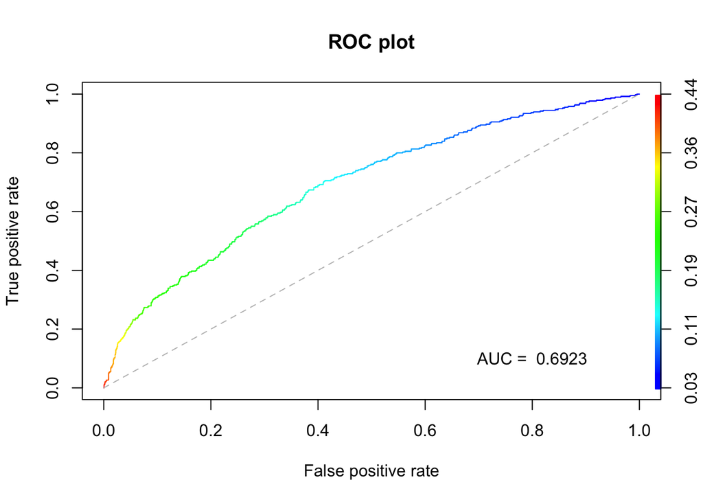

```r
# ROC curve
rocplot(PIAAC.reg$health_status_good, predict.glm(final5, PIAAC.reg, type = "response", na.action = na.omit), title = "ROC plot")
title(main = "ROC plot")
```

## Consider two additional predictors: Literacy and Problem solving abilities

```r
full6 <- glm(health_status_good ~ numeracy1 + age.cat + gender + educ +
               income.cat + race + hisp + literacy1 + problem_solving1,
             data = PIAAC.reg, family = "binomial")
final6 <- step(full6, direction = "both", trace = 0)
# fit6 <- glm(health_status_good ~ numeracy + educ + income.cat +
#                problem_solving, data = PIAAC.reg,
#             family = "binomial")
# summary(final6)
multi_summary6 <- exp(cbind(coef(final6), confint(final6))[-1, ]) %>%
  as.data.frame()
colnames(multi_summary6)[1] <- "OR"
multi_summary6$`p-val` <- summary(final6)$coefficients[-1, 4]

# power calculation
power6 <- powerSim(final6, nsim = 100, progress = FALSE)
auc6 <- auc(PIAAC.reg$health_status_good, predict.glm(final6, PIAAC.reg, type = "response", na.action = na.omit))
kable(multi_summary6) %>%
  kable_styling()
```

|  | OR | 2.5 % | 97.5 % | p-val |
| --- | --- | --- | --- | --- |
| numeracy1 | 1.0117345 | 1.0049236 | 1.0185997 | 0.0007126 |
| age.cat21-44 | 1.0583493 | 0.6260536 | 1.8785344 | 0.8388401 |
| age.cat45-64 | 1.6147884 | 0.9241639 | 2.9475532 | 0.1037190 |
| age.cat65+ | 1.5403863 | 0.7970143 | 3.0571767 | 0.2060573 |
| educSome college or associate’s degree | 0.7444098 | 0.5471399 | 1.0049618 | 0.0567547 |
| educBachelor’s degree or higher | 0.5463420 | 0.3960664 | 0.7497177 | 0.0002017 |
| income.cat$50k-$100k | 0.4971231 | 0.3788951 | 0.6490329 | 0.0000003 |
| income.cat$100k-$150k | 0.3162086 | 0.1997165 | 0.4838541 | 0.0000003 |
| income.cat$150k+ | 0.3266441 | 0.1966562 | 0.5218506 | 0.0000064 |
| literacy1 | 0.9900320 | 0.9828367 | 0.9972909 | 0.0071204 |
| problem_solving1 | 0.9913787 | 0.9853517 | 0.9974102 | 0.0052434 |

```r
# Calculate error rate
fit6.train <- glm(final6$call$formula, data = PIAAC.training,
            family = "binomial")
pred6 <- predict(fit6.train, PIAAC.test, type = "response")
pred6 <- ifelse(pred6 > .5, "Not Good", "Good")
err6 <- mean(pred6 != PIAAC.test$health_status_good)
```

Step-wise multivariate regression model was conducted. The final model has five significant predictors: numeracy, education, income,literacy and problem solving. The AUC is 0.7031865 with a power for numeracy of 0.96. The prediction error rate is 0.153.

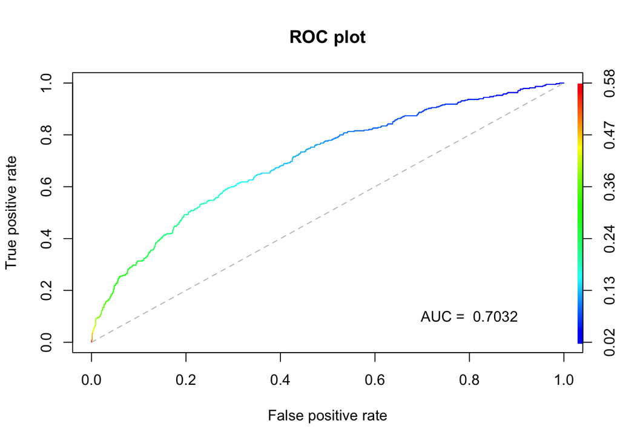

```r
rocplot(PIAAC.reg$health_status_good, predict.glm(final6, PIAAC.reg, type = "response", na.action = na.omit), title = "ROC plot")
title(main = "ROC plot")
```

# Summary

## ESP

#### Binary health status

```r
ESP_h1 <- c("health status: Good vs Not Good", "",
            round(auc1[1], 3),
            power1$x/power1$n, round(err1, 4), "\\*","", "\\*","\\*",
            "\\*","", "")
ESP_h2 <- c("health status: Good vs Not Good",
            "education, income", round(auc2[1], 3),
            power2$x/power2$n, round(err2, 4), "\\*", "", "\\*","\\*",
            "\\*","", "\\*")
ESP.result.health <- data.frame(ESP_h1, ESP_h2) %>% t() %>% as.data.frame()
rownames(ESP.result.health) <- NULL
colnames(ESP.result.health) <- c("Outcome", "Adjusted covariates", "AUC", "Power", "Prediction Error Rate", "numeracy", "gender", "age", "educ", "income", "race", "hisp")
ESP.result.health %>%
  kable(caption = "ESP's multivariates regression summary") %>%
  kable_styling() %>%
  add_header_above(c("Response" = 1, "Weights" = 1, "Performance"=3,"Predictor"=1,"Covariates"=6))
```

ESP’s multivariates regression summary

| Response Outcome | Weights Adjusted covariates | Performance AUC | Performance Power | Performance Prediction Error Rate | Predictor numeracy | Covariates gender | Covariates age | Covariates educ | Covariates income | Covariates race | Covariates hisp |
| --- | --- | --- | --- | --- | --- | --- | --- | --- | --- | --- | --- |
| health status: Good vs Not Good |  | 0.724 | 0.81 | 0.219 | * |  | * | * | * |  |  |
| health status: Good vs Not Good | education, income | 0.72 | 0.574 | 0.219 | * |  | * | * | * |  | * |

#### Visits to doctors by gender

```r
ESP_h3 <- c("visits to doctors: Never vs Not Regular vs Regular", "Female","",
             round(err3.female, 4), "", "", "","","", "")
ESP_h4 <- c("visits to doctors: Never vs Not Regular vs Regular", "Male", "",
            round(err3.male, 4), "\\*", "", "","\\*","", "")
ESP_h6 <- c("visits to doctors: Regular vs Not Regular", "Male",
            "Education",
            round(err4.male, 4), "\\*", "\\*", "\\*","\\*","", "\\*")

ESP.result.visits <- data.frame(ESP_h3, ESP_h4, ESP_h6) %>% t() %>% as.data.frame()
rownames(ESP.result.visits) <- NULL
colnames(ESP.result.visits) <- c("Outcome", "Gender", "Weights", "Prediction Error Rate", "numeracy", "age", "educ", "income", "race", "hisp")
ESP.result.visits %>%
  kable(caption = "ESP's multivariates regression summary") %>%
  kable_styling() %>%
  add_header_above(c("Response" = 3, "Performance"=1,"Predictor"=1,"Covariates"=5))
```

ESP’s multivariates regression summary

| Response Outcome | Response Gender | Response Weights | Performance Prediction Error Rate | Predictor numeracy | Covariates age | Covariates educ | Covariates income | Covariates race | Covariates hisp |
| --- | --- | --- | --- | --- | --- | --- | --- | --- | --- |
| visits to doctors: Never vs Not Regular vs Regular | Female |  | 0.3289 |  |  |  |  |  |  |
| visits to doctors: Never vs Not Regular vs Regular | Male |  | 0.3248 | * |  |  | * |  |  |
| visits to doctors: Regular vs Not Regular | Male | Education | 0.3047 | * | * | * | * |  | * |

## PIAAC - mean of all PVs

```r
PIAAC_h1 <- c("health status: Good vs Not Good", round(auc5[1], 3),
            power5$x/power5$n, round(err5, 4), "\\*", "", "\\*", "\\*",
            "\\*","", "","/", "/")
PIAAC_h2 <- c("health status: Good vs Not Good", round(auc6[1], 3),
            power6$x/power6$n, round(err6, 4), "\\*", "", "", "\\*", "\\*","", "","\\*", "\\*")

PIAAC.result <- data.frame(PIAAC_h1, PIAAC_h2) %>%
  t() %>%
  as.data.frame()
rownames(PIAAC.result) <- NULL
colnames(PIAAC.result) <- c("Outcome", "AUC", "Power", "Prediction Error Rate",
                        "numeracy", "gender", "age", "educ", "income", "race",
                        "hisp", "problem solving", "literacy")
PIAAC.result %>%
  kable(caption = "PIAAC's multivariates regression summary - mean of all PVs") %>%
  kable_styling() %>%
  add_header_above(c("Response" = 1, "Performance"=3,"Predictor"=1,"Covariates"=6, "Additional Predictor" = 2))
```

PIAAC’s multivariates regression summary - mean of all PVs

| Response Outcome | Performance AUC | Performance Power | Performance Prediction Error Rate | Predictor numeracy | Covariates gender | Covariates age | Covariates educ | Covariates income | Covariates race | Covariates hisp | Additional Predictor problem solving | Additional Predictor literacy |
| --- | --- | --- | --- | --- | --- | --- | --- | --- | --- | --- | --- | --- |
| health status: Good vs Not Good | 0.692 | 0.63 | 0.152 | * |  | * | * | * |  |  | / | / |
| health status: Good vs Not Good | 0.703 | 0.96 | 0.1533 | * |  |  | * | * |  |  | * | * |